# Final Project

Lillian Wei Hung

2021/12/5

# Bay Area

[output not shown]

1. Exposures has eight indicators as follows: Ozone (concentration), PM2.5 (concentration), Diesel PM (emissions), Drinking Water (index), Children’s Lead Risk from Housing (index), Pesticide Use (Ibs/sq. mi.), Toxic Releases (RSEI toxicity weighted releases), Traffic (impacts)
2. Environmental Effects has five indicators as follows: Cleanup Sites (weighted sites), Groundwater Threats (weighted sites), Hazardous Waste Facilities/ Generators (weighted sites), Impaired Water Bodies (number of pollutants), Solid Waste Sites/Facilities (weighted sites and facilities)
3. Sensitive Population has three indicators as follows: Asthma (rate per 10,000), Cardiovascular Disease (heart attacks per 10,000), Low Birth Weight (percent).
4. Socioeconomic Factor has five indicators as follows: Educational Attainment (percent), Housing Burden (percent), Linguistic Isolation (percent), Poverty (percent), Unemployment (percent)

   Cardiovascular Disease is an indicator representing the aspect of “Sensitive Population” in the CES score, which is the target variable considered in this project. The risk factors considered here will include all indicators in the other three sub-constructs: “Exposures”, “Environmental Effects”, and “Socioeconomic Factor”. Moreover, CalEnviroScreen also provides a demographic profile including the householder percentage of three age category variables and six racial category variables. These demographic variables will be also considered for the analysis since they are in the same macro-level as in CES data. The key questions in the project are as follow.

Question 1: What is the spatial distribution of Cardiovascular Disease prevalence in the Bay Area? Question 2: What risk factors are statistically associated with Cardiovascular Disease prevalence? Question 3: Are there any confounding effects among key risk factors? What do these confounding effect mean for the Cardiovascular Disease prevalence? Question 4: Could the key risk factors predict the the Cardiovascular Disease prevalence?

# ——————————————————————————

# Question 1: What is the spatial distribution of Cardiovascular Disease Prevalence in the Bay Area

# Spatial Distribution map of Cardiovascular Disease in Bay Area

[interactive chart not shown]

Results: The east and north-east sides of Bay areas particularly have high proportions of Cardiovascular Disease prevalence.

# ——————————————————————————

# Question 2: What risk factors are statistically associated with Cardiovascular Disease Prevalence?

# ——————————————————————————

# Use of correlation coefficients to inspect association

# Correlation of Exposures (predictors) with Cardiovascular Disease

Exposures (predictors): - Ozone (concentration) - PM2.5 (concentration) - Diesel PM (emissions) - Drinking Water (index) - Children’s Lead Risk from Housing (index) - Pesticide Use (Ibs/sq. mi.) - Toxic Releases (RSEI toxicity weighted releases - Traffic (impacts)

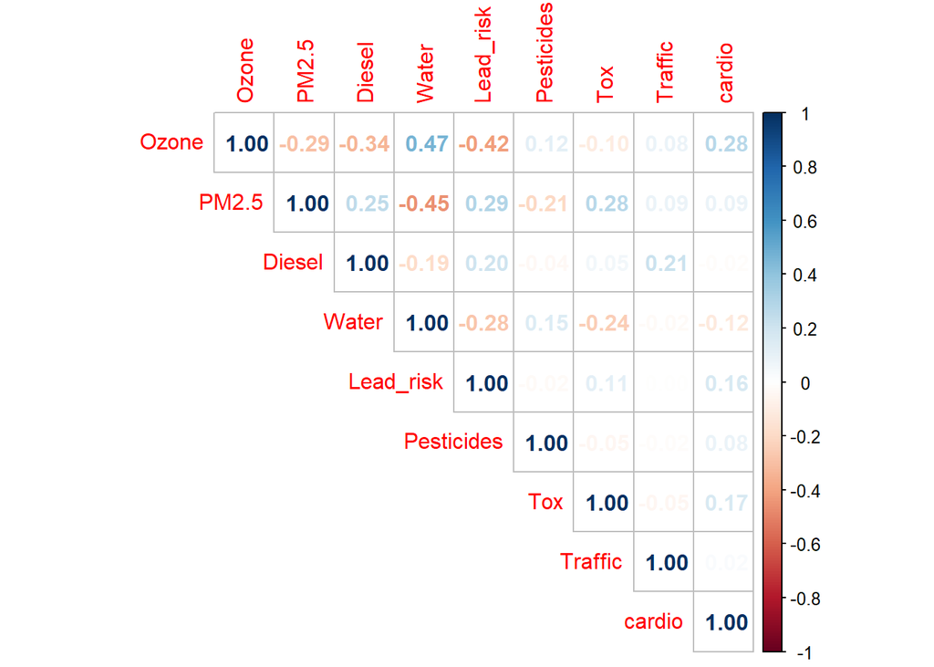

Result: Only Ozone (in the “Exposure” sub-construct) has correlation coefficient 0.28 with Cardiovascular Disease Prevalence , the other indicators all have correlation coefficient less than 0.2, indicating almost no or low correlation with Cardiovascular Disease..

# ——————————————————————————

# Correlation of Environmental Effects (predictors) with Cardiovascular Disease

Environmental Effects (predictors): - Cleanup Sites (weighted sites) - Groundwater Threats (weighted sites) - Hazardous Waste Factilities/ Generators (weighted sites) - Impaired Water Bodies (number of pollutants) - Solid Waste Sites/Facilities (weighted sites and facilities)

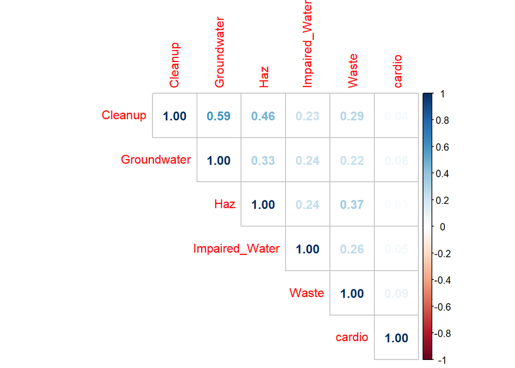

Result: All indicators in the sub-construct “Environmental Effects” have correlation coefficient less than 0.1, indicating no correlation with Cardiovascular Disease.

# ——————————————————————————

# Correlation of Socioeconomic Factos (predictors) with Cardiovascular Disease

Socioeconomic Factos (predictors): - Educational Attainment (percent - Housing Burden (percent) - Linguistic Isolation (percent) - Poverty (percent) - Unemployment (percent)

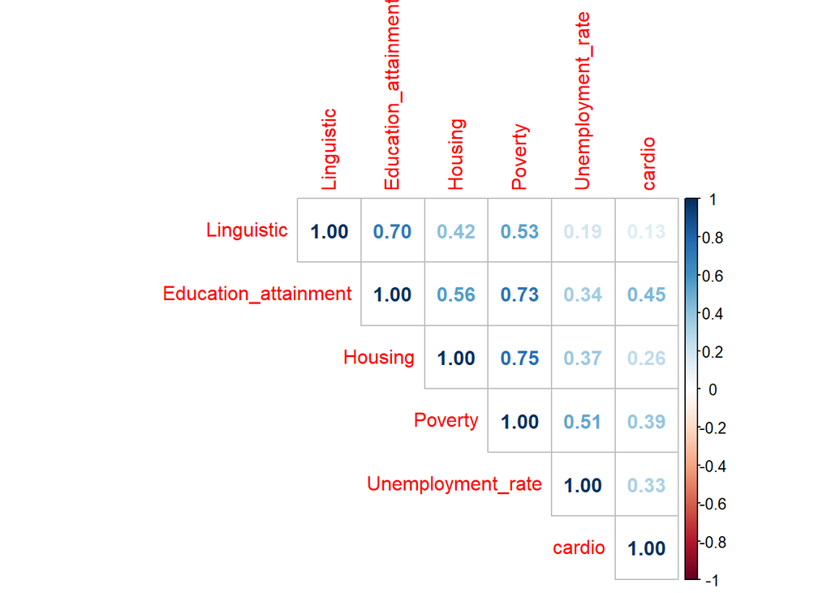

Result: Generally, as the correlation coefficient is less than 0.3, it is considered as low correlation. Hence, except for Linguistic Isolation and Housing Burden with correlation coefficient less than 0.3, the other three indicators have correlation coefficients ranging between 0.33 ~ 0.45, indicating the low to medium degree of correlation with Cardiovascular Disease. Educational Attainment has the highest correlation coefficient, followed by Poverty,and finally the Unemployment rate.

# ——————————————————————————

# Correlation of Demographic Factos (predictors) with Cardiovascular Disease

Demographic Factors (predictors): - under_10 (householder percentage in the census tract) - Year_11_to_64 - Elderly - Hispanic - White - African_American - Native_American - Asian_American - Other

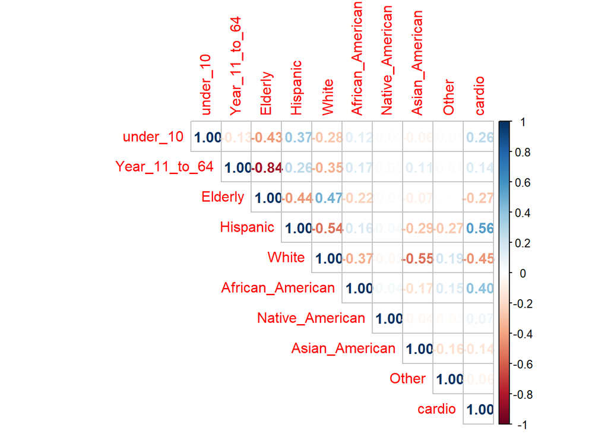

# ——————————————————————————

# Use of scatter plot to inspect association

# Key factors include Ozon, Edcation attainmen, Povert, Unemployment rate, Hispanic, White, African American

# ——————————–

# Plot of Ozone vs. Cardiovascular Disease

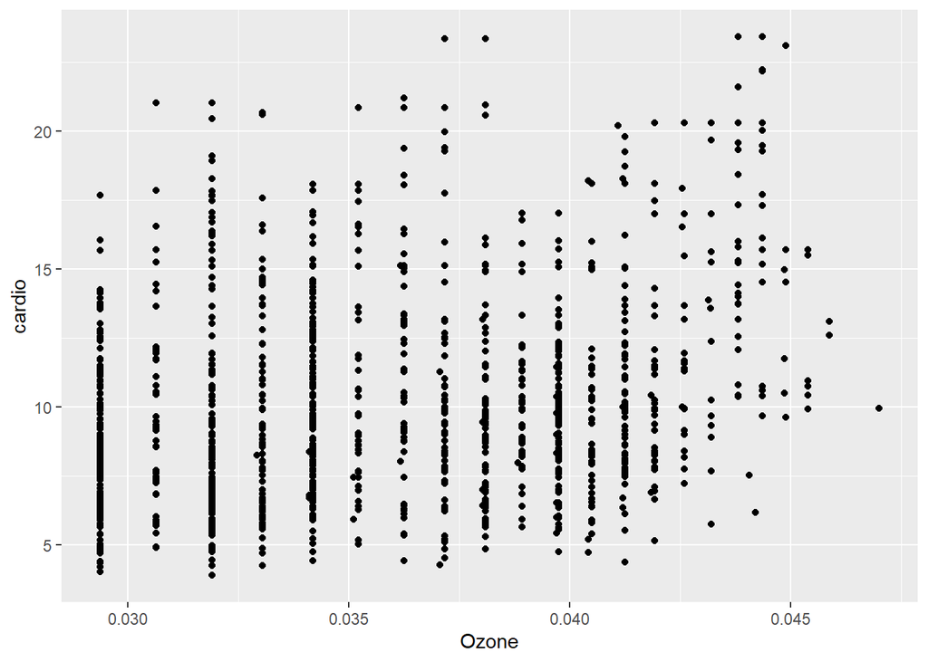

# Plot of Education attainment vs. Cardiovascular Disease

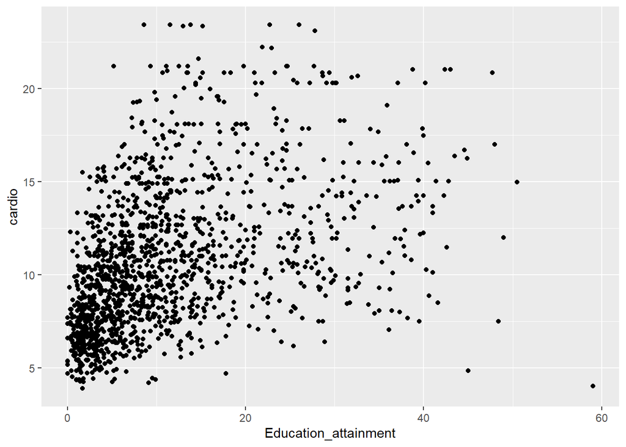

# Plot of Poverty vs. Cardiovascular Disease

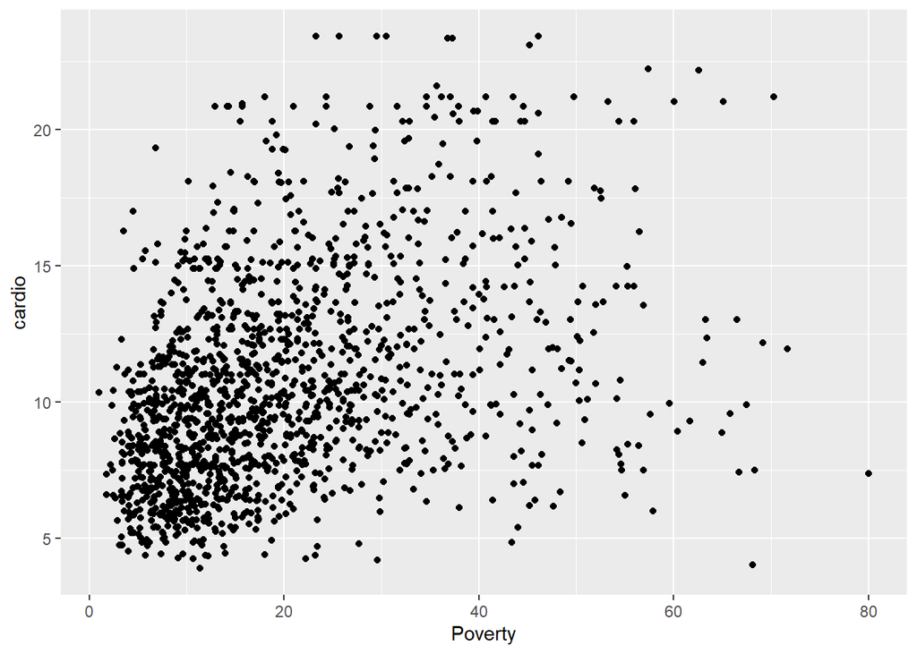

# Plot of Unemployment rate vs. Cardiovascular Disease

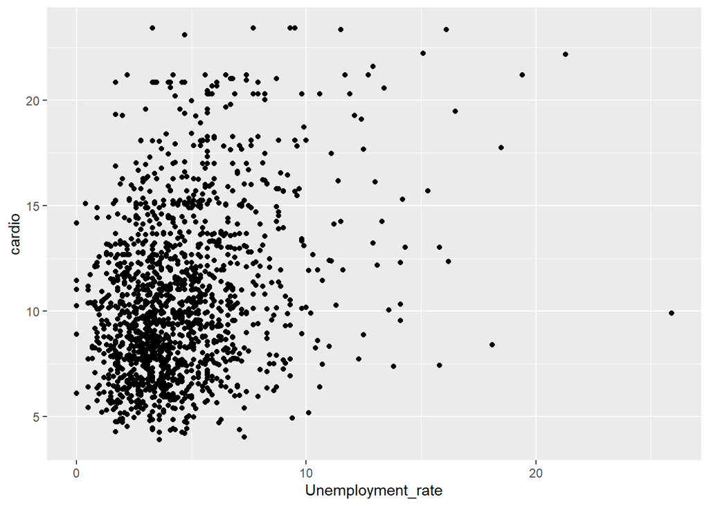

# Plot of Hispanic vs. Cardiovascular Disease

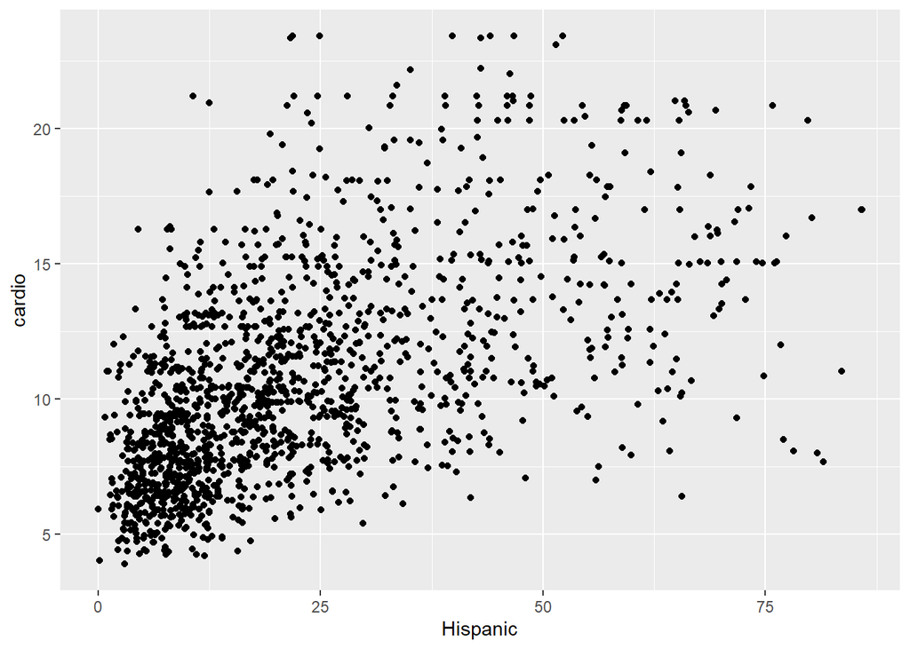

# Plot of White vs. Cardiovascular Disease

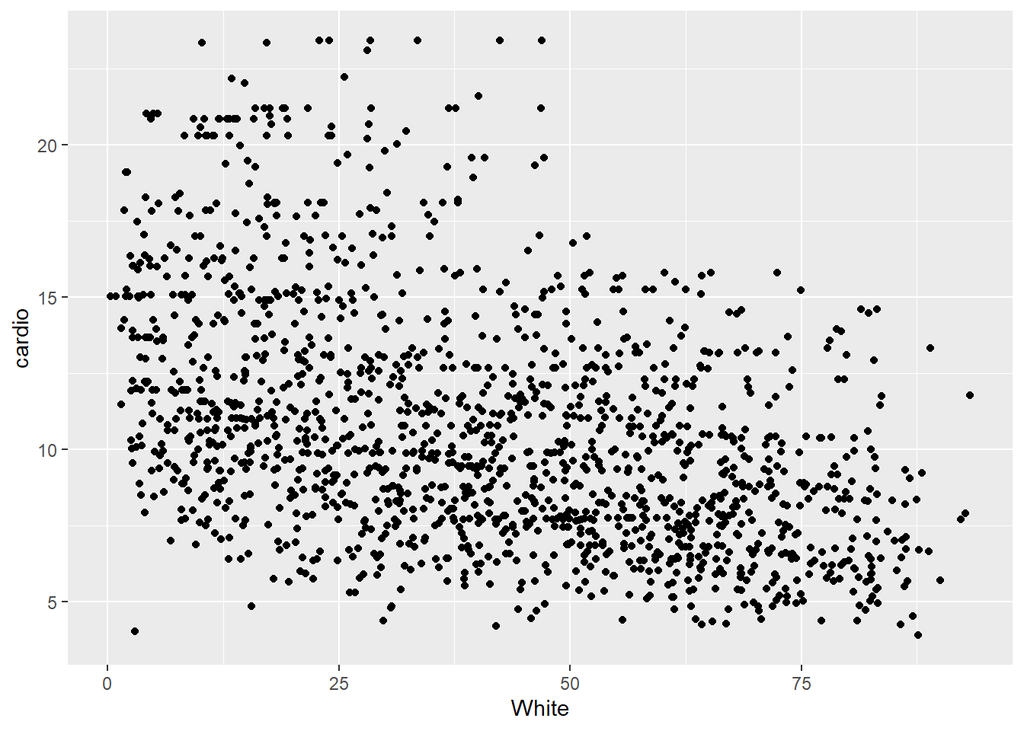

# Plot of African American vs. Cardiovascular Disease

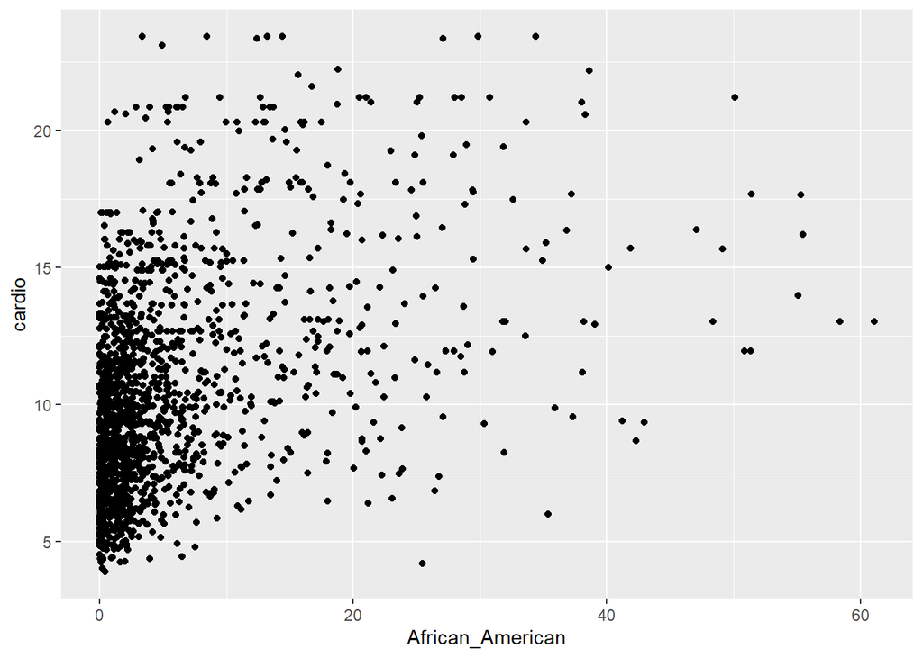

# Use of simple regression to examine the association between each key factor with Cardiovascular Disease Prevalence

# ——————————————————————————

# Fit simple regression model on Ozon, Edcation attainmen, Povert, Unemployment rate, Hispanic, White, African American, individually

# ——————————–

# Simple regression 1

# - Regress Cardiovascular Disease Prevalence on Ozone

```
##
## Call:
## lm(formula = cardio ~ Ozone, data = ces4_bay_all)
##
## Residuals:
##     Min      1Q  Median      3Q     Max
## -7.5521 -2.7482 -0.7795  2.2629 12.4101
##
## Coefficients:
##             Estimate Std. Error t value Pr(>|t|)
## (Intercept)   2.2025     0.7754    2.84  0.00457 **
## Ozone       235.6159    21.3913   11.02  < 2e-16 ***
## ---
## Signif. codes:  0 '***' 0.001 '**' 0.01 '*' 0.05 '.' 0.1 ' ' 1
##
## Residual standard error: 3.755 on 1482 degrees of freedom
## Multiple R-squared:  0.07567,    Adjusted R-squared:  0.07504
## F-statistic: 121.3 on 1 and 1482 DF,  p-value: < 2.2e-16
```

# Simple regression 2

# - Regress Cardiovascular Disease Prevalence on Education attainment

```
##
## Call:
## lm(formula = cardio ~ Education_attainment, data = ces4_bay_all)
##
## Residuals:
##      Min       1Q   Median       3Q      Max
## -14.9635  -2.4916  -0.5895   1.8583  13.2057
##
## Coefficients:
##                      Estimate Std. Error t value Pr(>|t|)
## (Intercept)          8.727983   0.135709   64.31   <2e-16 ***
## Education_attainment 0.173992   0.009023   19.28   <2e-16 ***
## ---
## Signif. codes:  0 '***' 0.001 '**' 0.01 '*' 0.05 '.' 0.1 ' ' 1
##
## Residual standard error: 3.492 on 1482 degrees of freedom
## Multiple R-squared:  0.2006, Adjusted R-squared:    0.2
## F-statistic: 371.9 on 1 and 1482 DF,  p-value: < 2.2e-16
```

# Simple regression 3

# - Regress Cardiovascular Disease Prevalence on Poverty

```
##
## Call:
## lm(formula = cardio ~ Poverty, data = ces4_bay_all)
##
## Residuals:
##      Min       1Q   Median       3Q      Max
## -12.0812  -2.5983  -0.5854   2.0970  12.3889
##
## Coefficients:
##             Estimate Std. Error t value Pr(>|t|)
## (Intercept) 8.404193   0.168495   49.88   <2e-16 ***
## Poverty     0.113172   0.006986   16.20   <2e-16 ***
## ---
## Signif. codes:  0 '***' 0.001 '**' 0.01 '*' 0.05 '.' 0.1 ' ' 1
##
## Residual standard error: 3.6 on 1482 degrees of freedom
## Multiple R-squared:  0.1504, Adjusted R-squared:  0.1499
## F-statistic: 262.4 on 1 and 1482 DF,  p-value: < 2.2e-16
```

# Simple regression 4

# - Regress Cardiovascular Disease Prevalence on Unemployment_rate

```
##
## Call:
## lm(formula = cardio ~ Unemployment_rate, data = ces4_bay_all)
##
## Residuals:
##      Min       1Q   Median       3Q      Max
## -10.8992  -2.7281  -0.5922   2.2535  13.3449
##
## Coefficients:
##                   Estimate Std. Error t value Pr(>|t|)
## (Intercept)         8.5221     0.1889   45.12   <2e-16 ***
## Unemployment_rate   0.4736     0.0358   13.23   <2e-16 ***
## ---
## Signif. codes:  0 '***' 0.001 '**' 0.01 '*' 0.05 '.' 0.1 ' ' 1
##
## Residual standard error: 3.694 on 1482 degrees of freedom
## Multiple R-squared:  0.1057, Adjusted R-squared:  0.105
## F-statistic: 175.1 on 1 and 1482 DF,  p-value: < 2.2e-16
```

# Simple regression 5

# - Regress Cardiovascular Disease Prevalence on Hispanic

```
##
## Call:
## lm(formula = cardio ~ Hispanic, data = ces4_bay_all_Demographic)
##
## Residuals:
##      Min       1Q   Median       3Q      Max
## -10.4593  -2.2474  -0.4886   1.7534  12.8208
##
## Coefficients:
##             Estimate Std. Error t value Pr(>|t|)
## (Intercept) 7.849872   0.137693   57.01   <2e-16 ***
## Hispanic    0.126113   0.004812   26.21   <2e-16 ***
## ---
## Signif. codes:  0 '***' 0.001 '**' 0.01 '*' 0.05 '.' 0.1 ' ' 1
##
## Residual standard error: 3.261 on 1508 degrees of freedom
## Multiple R-squared:  0.313,  Adjusted R-squared:  0.3125
## F-statistic: 686.9 on 1 and 1508 DF,  p-value: < 2.2e-16
```

# Simple regression 6

# - Regress Cardiovascular Disease Prevalence on White

```
##
## Call:
## lm(formula = cardio ~ White, data = ces4_bay_all_Demographic)
##
## Residuals:
##     Min      1Q  Median      3Q     Max
## -9.5521 -2.5907 -0.7307  1.9442 13.2024
##
## Coefficients:
##             Estimate Std. Error t value Pr(>|t|)
## (Intercept) 13.80865    0.18271   75.58   <2e-16 ***
## White       -0.07629    0.00391  -19.51   <2e-16 ***
## ---
## Signif. codes:  0 '***' 0.001 '**' 0.01 '*' 0.05 '.' 0.1 ' ' 1
##
## Residual standard error: 3.515 on 1508 degrees of freedom
## Multiple R-squared:  0.2016, Adjusted R-squared:  0.201
## F-statistic: 380.7 on 1 and 1508 DF,  p-value: < 2.2e-16
```

# Simple regression 7

# - Regress Cardiovascular Disease Prevalence on African American

```
##
## Call:
## lm(formula = cardio ~ African_American, data = ces4_bay_all_Demographic)
##
## Residuals:
##      Min       1Q   Median       3Q      Max
## -10.0836  -2.6500  -0.5545   2.0710  13.2052
##
## Coefficients:
##                  Estimate Std. Error t value Pr(>|t|)
## (Intercept)       9.60924    0.11306   84.99   <2e-16 ***
## African_American  0.18266    0.01073   17.03   <2e-16 ***
## ---
## Signif. codes:  0 '***' 0.001 '**' 0.01 '*' 0.05 '.' 0.1 ' ' 1
##
## Residual standard error: 3.603 on 1508 degrees of freedom
## Multiple R-squared:  0.1613, Adjusted R-squared:  0.1607
## F-statistic:   290 on 1 and 1508 DF,  p-value: < 2.2e-16
```

Result:

The predictors, Ozone, Education attainment, Poverty, Unemployment rate, Hispanic, White and African American are all very significant with p value less than 0.001 in each individual simple regression model. The expansionary power of the seven simple regression models ranges from 0.07567 to 0.313. The order of the key factors regarding the model expansionary power (R square) from the highest to the lowest is as follows: Hispanic > White > Education attainment > African American > Poverty > Unemployment rate > Ozone.